# Homework Week 13

Annanina Koster

12 januari 2016

The homework [14 I 2016]

Let’s download a toy dataset with two interesting variables, namely thick and soil. We would like to check if there is any relation between these two variables.

Try two models: simple linear regression model with just one dependent variable and a model which takes into account spatial structure of measurements (variables east and north).

Compare these two models and answer the question: is there a significant relation between variables thick (y) and soil (dependent variable)?

See this page for some hints.

Sources:

http://www.ats.ucla.edu/stat/r/faq/spatial_regression.htm http://www.ats.ucla.edu/stat/r/faq/variogram_lme.htm https://rawgit.com/pbiecek/LinearModels/master/MIMUW_2015/MaterialyPomocnicze/13_spatial.html

For this homework, I will be looking at a dataset with two interesting variables: thick and soil. The question to answer is whether there is a significant relationship between these two (with thick being the dependent variable and soil the independent). In order to answer this question, two models will be compared: a simple linear regression model and a model which takes into account the spatial structure of the measurements (using the variables east and north).

First of all, I will load and inspect the dataset. Then, I will plot the relation between the important variables thick and soil. It seems that there isn’t a very obvious relation between the two. Maybe a slightly positive one. Afterwards, I will fit the simplest linear model as model0. As can be seen in the summary, the relation between thick and soil is significantly different from 0 at a 5% confidence level. Another simple linear model is given by model1, which uses the dummy variable that is 1 for all oberservations as the random effect. (As expected there is almost no random effect) As can also be seen from this summary, the relation would now also be significant at a 5% confidence level.

```r
spdata <- read.table("http://www.ats.ucla.edu/stat/r/faq/thick.csv", header = T, sep = ",")
head(spdata) #this dataset already has a dummy variable that equals one for all observations
```

```
##   X east north thick     soil dummy
## 1 1  0.7  59.6  34.1 3.635764     1
## 2 2  2.1  82.7  42.2 3.502083     1
## 3 3  4.7  75.1  39.5 3.946545     1
## 4 4  4.8  52.8  34.3 2.941715     1
## 5 5  5.9  67.1  37.0 3.866264     1
## 6 6  6.0  35.7  35.9 3.018548     1
```

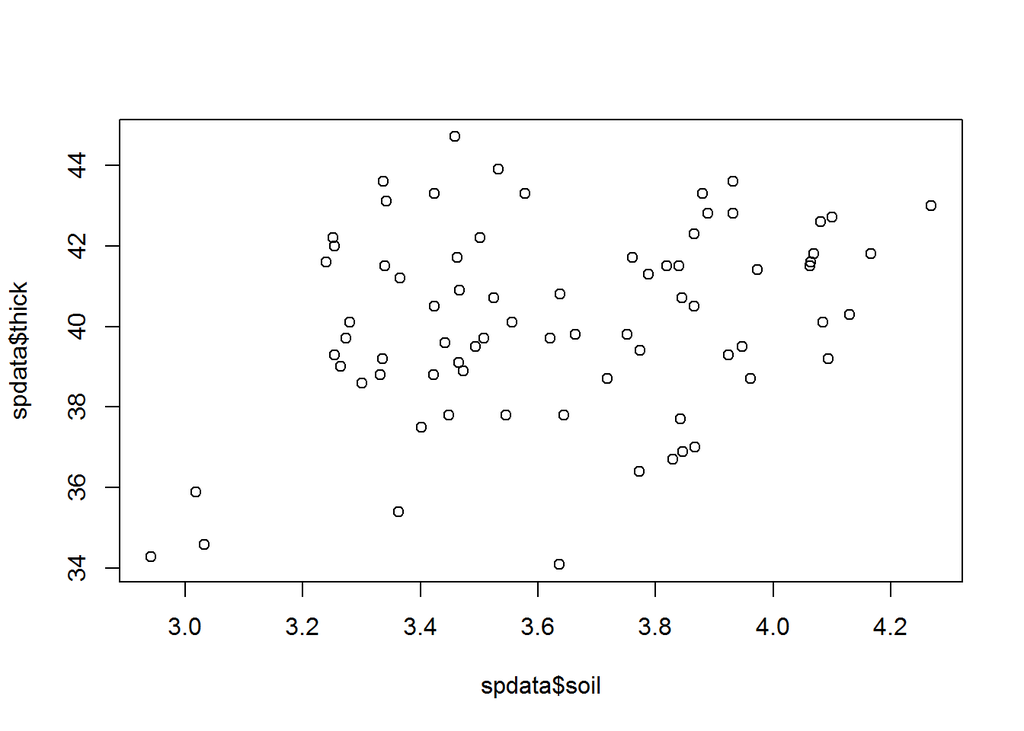

```r
plot(spdata$soil, spdata$thick)

library(nlme)
```

```r
model0 <- lm(thick~soil, data=spdata)
summary(model0)
```

```
##
## Call:
## lm(formula = thick ~ soil, data = spdata)
##
## Residuals:
##     Min      1Q  Median      3Q     Max
## -6.0414 -1.1975  0.0876  1.4836  4.9584
##
## Coefficients:
##             Estimate Std. Error t value Pr(>|t|)
## (Intercept)  31.9420     3.1570  10.118 1.54e-15 ***
## soil          2.2552     0.8656   2.605   0.0111 *
## ---
## Signif. codes:  0 '***' 0.001 '**' 0.01 '*' 0.05 '.' 0.1 ' ' 1
##
## Residual standard error: 2.278 on 73 degrees of freedom
## Multiple R-squared:  0.08508,    Adjusted R-squared:  0.07254
## F-statistic: 6.788 on 1 and 73 DF,  p-value: 0.01111
```

```r
model1 <- lme(thick ~ soil, data=spdata, random= ~1|dummy, method="ML")
summary(model1)
```

```
## Linear mixed-effects model fit by maximum likelihood
##  Data: spdata
##        AIC      BIC    logLik
##   342.3182 351.5881 -167.1591
##
## Random effects:
##  Formula: ~1 | dummy
##          (Intercept) Residual
## StdDev: 4.815352e-05 2.247569
##
## Fixed effects: thick ~ soil
##                Value Std.Error DF   t-value p-value
## (Intercept) 31.94203 3.1569891 73 10.117878  0.0000
## soil         2.25521 0.8655887 73  2.605407  0.0111
##  Correlation:
##      (Intr)
## soil -0.997
##
## Standardized Within-Group Residuals:
##         Min          Q1         Med          Q3         Max
## -2.68798974 -0.53279498  0.03896491  0.66007203  2.20612991
##
## Number of Observations: 75
## Number of Groups: 1
```

Since these models don’t really seem to agree with the plot, I will now try to include the other two variables: east and north, to account for the spatial structure of measurements. Different types of spatial correlation structures will be tried, and the best model will be selected.

```r
model2 <- update(model1, correlation = corExp(form = ~ east + north), method = "ML")
summary(model2) #AIC: 169.1041, BIC: 180.6915, logLik: -79.55203
```

```
## Linear mixed-effects model fit by maximum likelihood
##  Data: spdata
##        AIC      BIC    logLik
##   169.1041 180.6915 -79.55203
##
## Random effects:
##  Formula: ~1 | dummy
##         (Intercept) Residual
## StdDev: 0.000441674 2.960998
##
## Correlation Structure: Exponential spatial correlation
##  Formula: ~east + north | dummy
##  Parameter estimate(s):
##   range
## 205.623
## Fixed effects: thick ~ soil
##                Value Std.Error DF   t-value p-value
## (Intercept) 42.31577 2.5992995 73 16.279681  0.0000
## soil         0.02578 0.2011283 73  0.128195  0.8983
##  Correlation:
##      (Intr)
## soil -0.253
##
## Standardized Within-Group Residuals:
##        Min         Q1        Med         Q3        Max
## -2.8063204 -1.2000998 -0.7768787 -0.2242907  0.7750977
##
## Number of Observations: 75
## Number of Groups: 1
```

```r
model3 <- update(model1, correlation = corGaus(form = ~ east + north), method = "ML")
summary(model3) #AIC: 91.50733, BIC: 103.0948, logLik: -40.75366
```

```
## Linear mixed-effects model fit by maximum likelihood
##  Data: spdata
##        AIC      BIC    logLik
##   91.50733 103.0948 -40.75366
##
## Random effects:
##  Formula: ~1 | dummy
##          (Intercept) Residual
## StdDev: 7.497427e-05 2.088388
##
## Correlation Structure: Gaussian spatial correlation
##  Formula: ~east + north | dummy
##  Parameter estimate(s):
##    range
## 20.43726
## Fixed effects: thick ~ soil
##                Value Std.Error DF  t-value p-value
## (Intercept) 40.32797 0.5877698 73 68.61184  0.0000
## soil         0.00348 0.0160363 73  0.21693  0.8289
##  Correlation:
##      (Intr)
## soil -0.102
##
## Standardized Within-Group Residuals:
##        Min         Q1        Med         Q3        Max
## -2.9882458 -0.7133759 -0.1146242  0.6745680  2.0877341
##
## Number of Observations: 75
## Number of Groups: 1
```

```r
model4 <- update(model1, correlation = corSpher(form = ~ east + north), method = "ML")
summary(model4) #AIC: 344.3183, BIC: 355.9058, logLik: -167.1592
```

```
## Linear mixed-effects model fit by maximum likelihood
##  Data: spdata
##        AIC      BIC    logLik
##   344.3183 355.9058 -167.1592
##
## Random effects:
##  Formula: ~1 | dummy
##          (Intercept) Residual
## StdDev: 4.767071e-05 2.247574
##
## Correlation Structure: Spherical spatial correlation
##  Formula: ~east + north | dummy
##  Parameter estimate(s):
##    range
## 1.676108
## Fixed effects: thick ~ soil
##                Value Std.Error DF   t-value p-value
## (Intercept) 31.94205  3.157311 73 10.116855  0.0000
## soil         2.25519  0.865658 73  2.605179  0.0111
##  Correlation:
##      (Intr)
## soil -0.997
##
## Standardized Within-Group Residuals:
##         Min          Q1         Med          Q3         Max
## -2.68796893 -0.53277540  0.03898215  0.66008992  2.20614019
##
## Number of Observations: 75
## Number of Groups: 1
```

```r
model5 <- update(model1, correlation = corLin(form = ~ east + north), method = "ML")
summary(model5) #AIC: 167.4697, BIC: 179.0571, logLik: -78.73483
```

```
## Linear mixed-effects model fit by maximum likelihood
##  Data: spdata
##        AIC      BIC    logLik
##   167.4697 179.0571 -78.73483
##
## Random effects:
##  Formula: ~1 | dummy
##          (Intercept) Residual
## StdDev: 8.226784e-13  2.28341
##
## Correlation Structure: Linear spatial correlation
##  Formula: ~east + north | dummy
##  Parameter estimate(s):
##    range
## 124.2619
## Fixed effects: thick ~ soil
##                Value Std.Error DF   t-value p-value
## (Intercept) 43.07625 1.4945435 73 28.822347  0.0000
## soil         0.02670 0.1995955 73  0.133784  0.8939
##  Correlation:
##      (Intr)
## soil -0.42
##
## Standardized Within-Group Residuals:
##        Min         Q1        Med         Q3        Max
## -3.9735896 -1.8906392 -1.3417805 -0.6254307  0.6706634
##
## Number of Observations: 75
## Number of Groups: 1
```

```r
model6 <- update(model1, correlation = corRatio(form = ~ east + north), method = "ML")
summary(model6) #AIC: 56.02011, BIC: 67.60755, logLik: -23.01006
```

```
## Linear mixed-effects model fit by maximum likelihood
##  Data: spdata
##        AIC      BIC    logLik
##   56.02011 67.60755 -23.01006
##
## Random effects:
##  Formula: ~1 | dummy
##          (Intercept) Residual
## StdDev: 0.0001668291 2.553949
##
## Correlation Structure: Rational quadratic spatial correlation
##  Formula: ~east + north | dummy
##  Parameter estimate(s):
##    range
## 33.15114
## Fixed effects: thick ~ soil
##                Value Std.Error DF   t-value p-value
## (Intercept) 40.93084 1.3340839 73 30.680860  0.0000
## soil        -0.00414 0.0170917 73 -0.242092  0.8094
##  Correlation:
##      (Intr)
## soil -0.028
##
## Standardized Within-Group Residuals:
##        Min         Q1        Med         Q3        Max
## -2.6687290 -0.8091690 -0.3186996  0.3270844  1.4814190
##
## Number of Observations: 75
## Number of Groups: 1
```

As can be seen from these summaries, the model with rational quadratics as the spatial correlation structure is best. Hence, this will be the final model. In this model, the p-value of soil is quite high. Therefore it can be concluded that the model that takes into account the spatial structure of the measurements (rational quadratics) is the best model for this dataset, and it shows that there is no significant relationship between the important variables thick and soil.